# avocado

Andrew Chen

2023-05-01

Team Members: Andrew Chen, Vrinda Vegiraju, Kennedy Wendl

```r
avo = read.csv("avocado.csv", header = TRUE)
#avo
```

We will be using the avocados data set from https://www.kaggle.com/datasets/neuromusic/avocado-prices. The data was collected by the Hass Avocado Board website. There are 14 variables in this data set. X is the index. Date is the date of when the data was observed. AveragePrice is the average price of one avocado. Total_Volume is the total number of avocados sold. 4046,4225,4770 are the PLU codes, which is the weight of the avocado. 4046 is 3-5 oz, 4225 is 8-10 oz, 4770 is 10-15 oz. Total_Bags is the total number of bags sold. Small_Bags is the number of small bags sold. Large_Bags is the number of large bags sold. XLarge_Bags is the number of extra large bags sold. Type is the type of avocado (conventional or organic). Year is the year that the data was observed. Region is the location of where the data was observed.

The data is already cleaned from what we can see.

Scatter

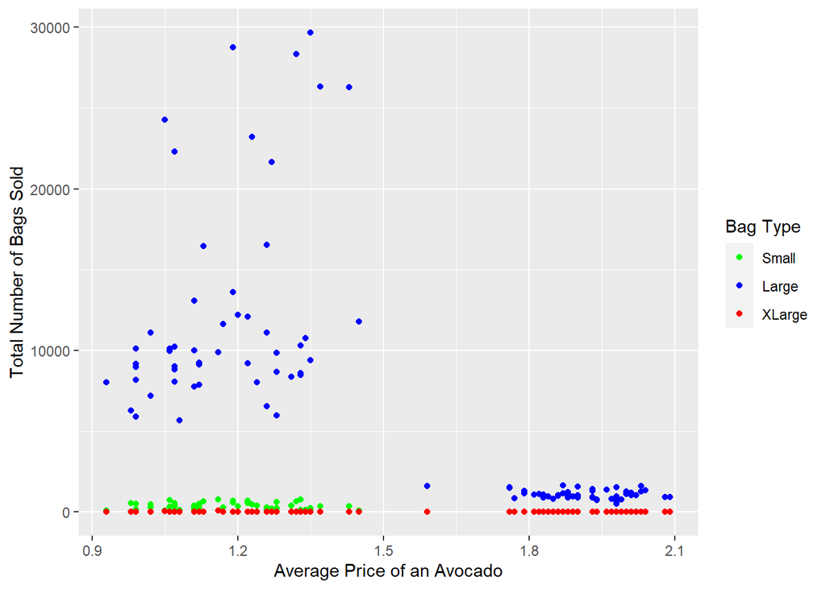

```r
#Kennedy
avo_scatter = avo
avo_scatter <- avo_scatter %>% filter(region == "Albany" & year == "2015")

#Plotting the data
scatterPlot = ggplot(avo_scatter, aes(x = AveragePrice,
                                      y = Total_Bags,
                                      color = variable)) +
  geom_point(aes(y = Small_Bags, color = "green")) +
  geom_point(aes(y = Large_Bags, color = "blue")) +
  geom_point(aes(y = XLarge_Bags, color = "red")) +
  scale_color_manual(labels = c("Small", "Large", "XLarge"),
                     values = c("green", "blue", "red"))

print(scatterPlot + labs(x = "Average Price of an Avocado",
                         y = "Total Number of Bags Sold",
                         color = "Bag Type"))
```

For the scatter plot, I decided to focus on the number of bags sold in Albany during 2015. I wanted to determine if one type was sold more frequently depending on the average price of an avocado.

Line

[figure not shown]

```r
#Vrinda
avo_line = avo

linePlot = ggplot(avo_line, aes(x = AveragePrice, y = Date)) + geom_line() +
  facet_wrap(~year)

print(linePlot + labs(x = "The type of Avocados",
                     y = "The Date Sold"))
```

Time Series

```r
#Andrew
#Time Series
avo_time = avo
avo_time2 <- avo_time %>%
  mutate(Date = as.Date(Date)) %>%
  group_by(year = lubridate::year(Date), month = lubridate::month(Date)) %>%
  summarise(ave_price = mean(AveragePrice))
```

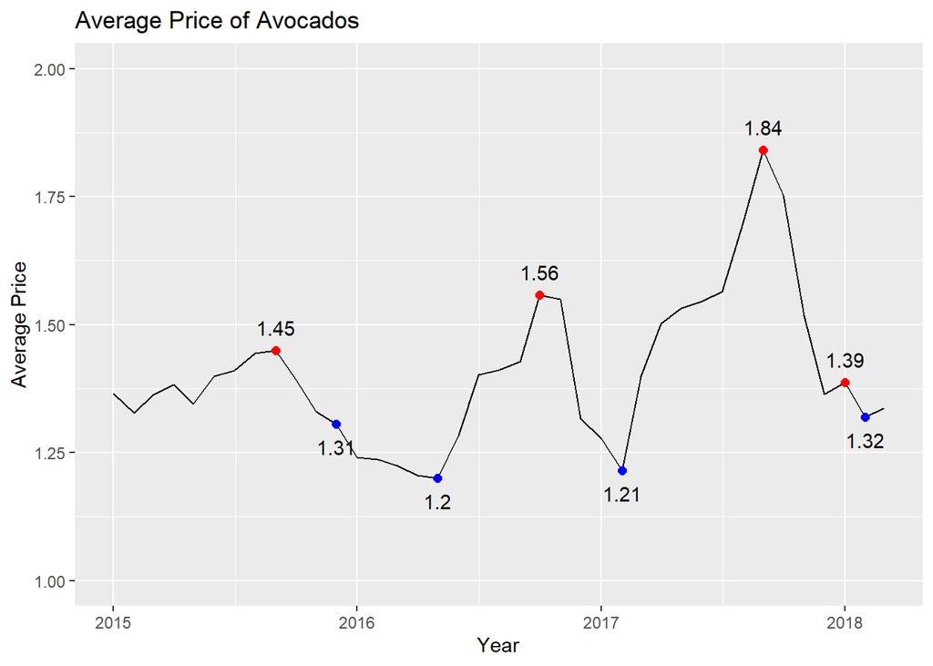

```r
#Most expensive
avo_time_most <- avo_time2 %>% slice_max(ave_price)

#Least expensive
avo_time_least <- avo_time2 %>% slice_min(ave_price)

#Make Graph
ggplot(data = avo_time2, aes(x = as.Date(paste(year, month, "01", sep = "-")), y = ave_price)) +
  geom_line() +
  geom_point(data = avo_time_most, aes(x = as.Date(paste(year, month, "01", sep = "-")),
                                       y = ave_price), size = 2, color = "red") +
  geom_text(data = avo_time_most, aes(label=round(ave_price, 2),
                                      x = as.Date(paste(year, month, "01", sep = "-")),
                                      y = ave_price), vjust = -1) +
  geom_point(data = avo_time_least, aes(x = as.Date(paste(year, month, "01", sep = "-")),
                                       y = ave_price), size = 2, color = "blue") +
  geom_text(data = avo_time_least, aes(label=round(ave_price, 2),
                                      x = as.Date(paste(year, month, "01", sep = "-")),
                                      y = ave_price), vjust = 2) +
  labs(title = "Average Price of Avocados", x = "Year", y = "Average Price") +
  ylim(1, 2)
```

This time series plot shows the average price of avocados by year. The average max price of avocados is going up, while the min price is about the same. In 2015, the most expensive was $1.45. In 2016, it was $1.56. In 2017, it was $1.84.

Box

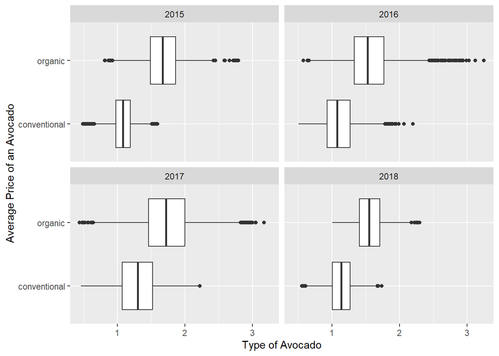

```r
#Kennedy
avo_box = avo

#Plotting the data
boxPlot = ggplot(avo_box, aes(x = AveragePrice, y = type)) + geom_boxplot() +
  facet_wrap(~year)

print(boxPlot + labs(x = "Type of Avocado",
                     y = "Average Price of an Avocado"))
```

That being said, the data for 2018 is incomplete and the prices could be greater if we were given more information. Additionally, the spread for all years, except 2018, is relatively large. This is due to the amount of data the plot accounts for.

Bar

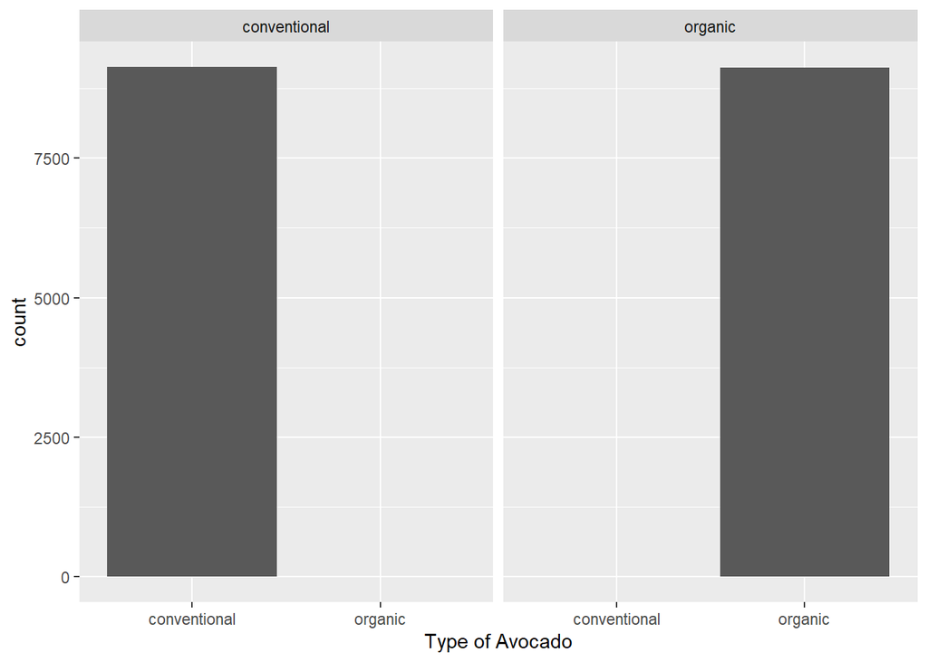

```r
#Vrinda

avo_bar = avo
barPlot = ggplot(avo_bar, aes(x = type)) + geom_bar() +
  facet_wrap(~type)

print(barPlot + labs(x = "Type of Avocado"))
```

As shown in the bar plot, we can clearly see the difference between the two types of avacados: The conventional versus organic avacados The count ranges from 0 to 7500 and based on the bar plot, we can see the similarity between the two types of avacados, both being very high, above 7500.

Histogram

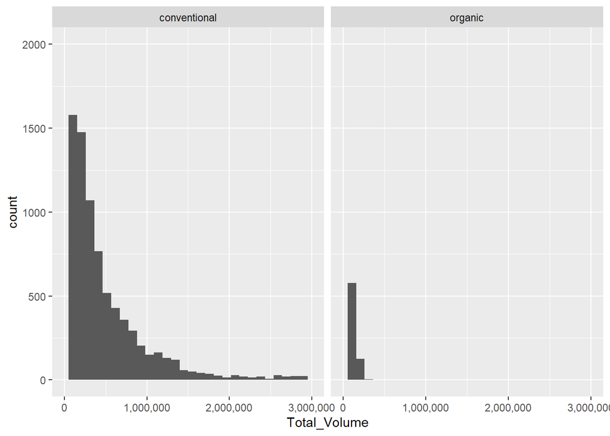

```r
#Andrew
avo_hist = avo
avo_hist2 <- subset(avo_hist, !(region %in% c("Midsouth", "Northeast", "SouthCentral",
                                              "Southeast", "West", "TotalUS" )))

ggplot(data = avo_hist2, aes(x = Total_Volume)) +
  geom_histogram() +
  scale_x_continuous(limits = c(0, 3000000), labels = scales::comma_format()) +
  coord_cartesian(ylim = c(0, 2000)) +
  facet_wrap(~type)
```

Some of the data was cut off to make the graphs more readable. More conventional type avocados were sold and at greater volumes. Organic type avocados has under 500,000 in volume. Overall, avocados were bought in smaller volumes.